# Lab-08

Ehshan Veerabangsa

29 November 2017

# SVM on Linear separable dataset

## Generate Linearly Separable Data

```r
# Set seed
set.seed(300)

# Observations
observations <- 100

# Features
feaures <- 2

# Data points for each class
data_points <- observations * feaures

# Cluster means
pos_mean <- 0
neg_mean <- 3

postive = matrix(rnorm(data_points, mean = pos_mean), nrow = 100, ncol = 2)
negative = matrix(rnorm(data_points, mean = neg_mean), nrow = 100, ncol = 2)
```

We will now simulate labels for the dataset.

```r
labels <- c(rep(1, 100), rep(-1, 100))
```

Next, we bind the dataset to one variable and populate a dataframe.

```r
obs <- rbind(postive, negative)

data <- data.frame(x = obs, y = as.factor(labels))
```

The next step is to visualise the dataset with a plot.

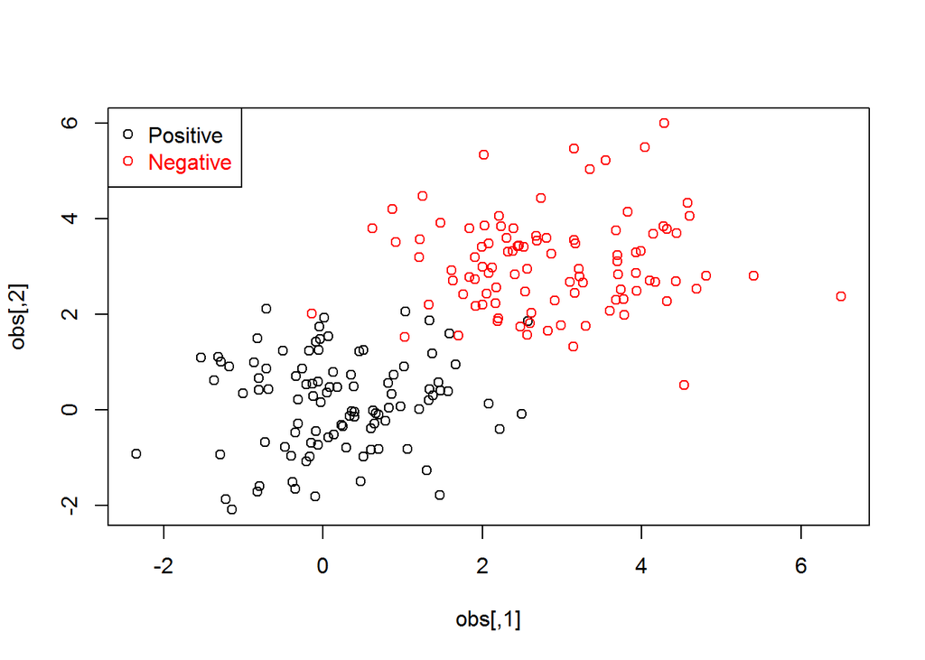

```r
plot(obs, col=ifelse( labels > 0, 1, 2))

legend("topleft",c("Positive","Negative"),col=seq(2),pch=1,text.col=seq(2))
```

Finally we can split our data into training and test sets by a 70/30 split

```r
# Split data into training & test sets

set.seed(300)

train_indices <- sample(200, 200 * 0.7)

training_set <- data[train_indices, ]

test_obs <- obs[-train_indices, ]
test_labels <- labels[-train_indices]
```

## Part 1: Load SVM Library

Before we begin our experiements, we will need to load the apporate library.

```r
#install.packages("e1071")
library(e1071)
```

## Part 2: Linear SVM with cost = 1

Now we can fit a linear SVM with a cost parameter of 1.

```r
linear_fit_1 = svm(y~.,data = training_set, kernel = "linear",cost = 1)
```

## Part 3: Report Results

The next step is to check the figures from our new model.

```r
summary(linear_fit_1)
```

```
##
## Call:
## svm(formula = y ~ ., data = training_set, kernel = "linear",
##     cost = 1)
##
##
## Parameters:
##    SVM-Type:  C-classification
##  SVM-Kernel:  linear
##        cost:  1
##       gamma:  0.5
##
## Number of Support Vectors:  15
##
##  ( 7 8 )
##
##
## Number of Classes:  2
##
## Levels:
##  -1 1
```

## Part 4: Linear SVM Plot

We will now visualise our model.

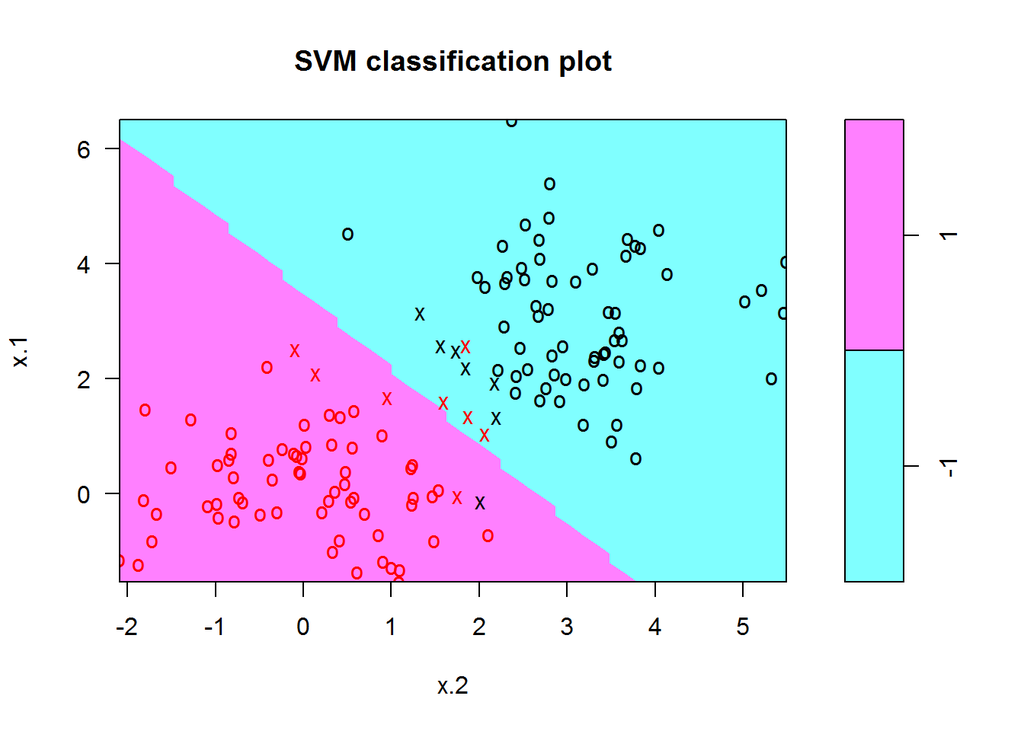

```r
plot(linear_fit_1, training_set)
```